# 5_Data visualisation

```r
library(tidyverse)
library(here)
entrevistas <- read_csv(
  here("data", "SAFI_clean.csv"),
  na = "NULL"
)
```

```r
# transformación previa (Dependencias)
interviews_plotting <- entrevistas %>%
  ## pivot wider by items_owned
  separate_rows(items_owned, sep = ";") %>%
  ## if there were no items listed, changing NA to no_listed_items
  replace_na(list(items_owned = "no_listed_items")) %>%
  mutate(items_owned_logical = TRUE) %>%
  pivot_wider(names_from = items_owned,
              values_from = items_owned_logical,
              values_fill = list(items_owned_logical = FALSE)) %>%
  ## pivot wider by months_lack_food
  separate_rows(months_lack_food, sep = ";") %>%
  mutate(months_lack_food_logical = TRUE) %>%
  pivot_wider(names_from = months_lack_food,
              values_from = months_lack_food_logical,
              values_fill = list(months_lack_food_logical = FALSE)) %>%
  ## add some summary columns
  mutate(number_months_lack_food = rowSums(select(., Jan:May))) %>%
  mutate(number_items = rowSums(select(., bicycle:car)))

write_csv(interviews_plotting, file = "interviews_plotting.csv")
```

vamos a usar el paquete ggplot2 que está en tidyverse:

```r
interviews_plotting <- read_csv("interviews_plotting.csv")
```

ggplot2 aporta una interfaz para especificar las variables, la forma de presentarlas y las propiedades visuales este trabajo en capas permite que sea fácil mutar de un tipo de gráfico a otro trabaja mejor con datos en formato long (una columna por cada dimensión y una fila por cada observación)

cada gráfico debe aportar: * datos * mapeo de la estética (descripción de cómo las variables se mapean a los atributos gráficos y los atributos visuales de los datos, como el eje y y el x, el color, el relleno, la forma y la transparencia) * objetos geométricos (geoms), básicamente tipo de gráfico

entonces, la plantilla para el código sería esta:

DATA %>% ggplot(aes(MAPPINGS)) + GEOM_FUNCTION()

ejemplo:

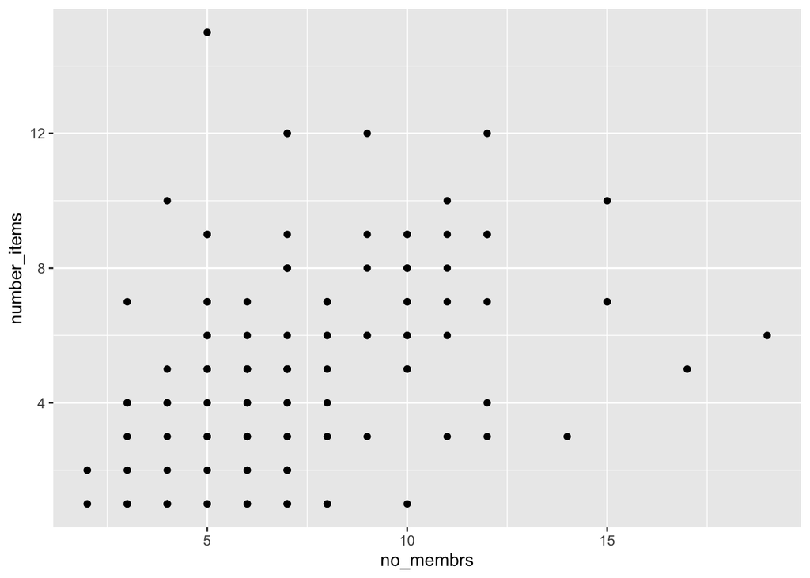

```r
interviews_plotting %>% # data
  ggplot(aes(x = no_membrs, y = number_items))+ # define el mapeo con las variables, la estética
  geom_point() # tipo de gráfico
```

```r
# el paquete ggplot usa + en lugar de pipes, ojo
```

algunas cuestiones importantes: * todo lo que vaya dentro de la funcion ggplot() puede ser accedido por cualqquier capa de geom * podés dar mappings específicos para cada geom * el signo + hay que ponerlo siempre al final de la linea

# Construir gráficos de forma interactiva

si miramos el gráfico anterior vemos que hay menos puntos que filas de observciones y que todos los puntos parecen estar en la intersección de las variables. parecería ser que hay observaciones superpuestas se puede resolver: 1) cambiando transparencia, 2) agregando movimiento/temblor a los puntos (jittering)

opción 1: argumento alpha, que va de 0 a 1.

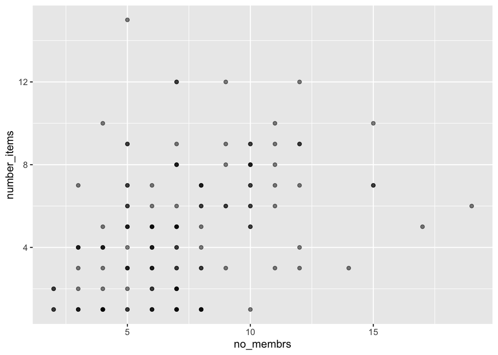

```r
interviews_plotting %>%
    ggplot(aes(x = no_membrs, y = number_items)) +
    geom_point(alpha = 0.5)
```

opción 2:

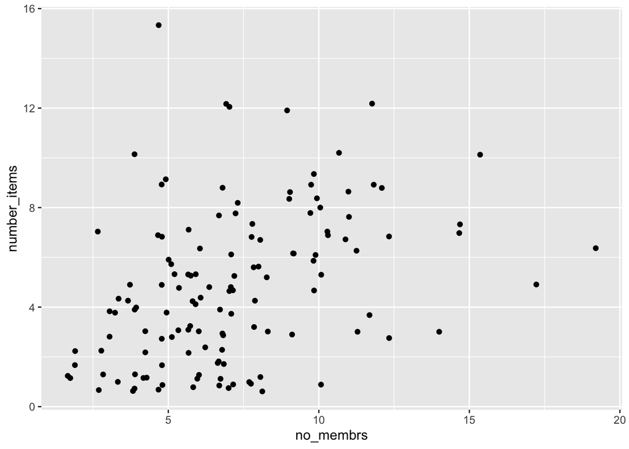

```r
interviews_plotting %>%
    ggplot(aes(x = no_membrs, y = number_items)) +
    geom_jitter()
```

```r
# podemos especificar la cantidad de movimiento y el color
# geom_jitter(alpha = 0.5,
#                 color = "blue",
                # width = 0.2,
                # height = 0.2)
```

si quiero asignar distintos colores:

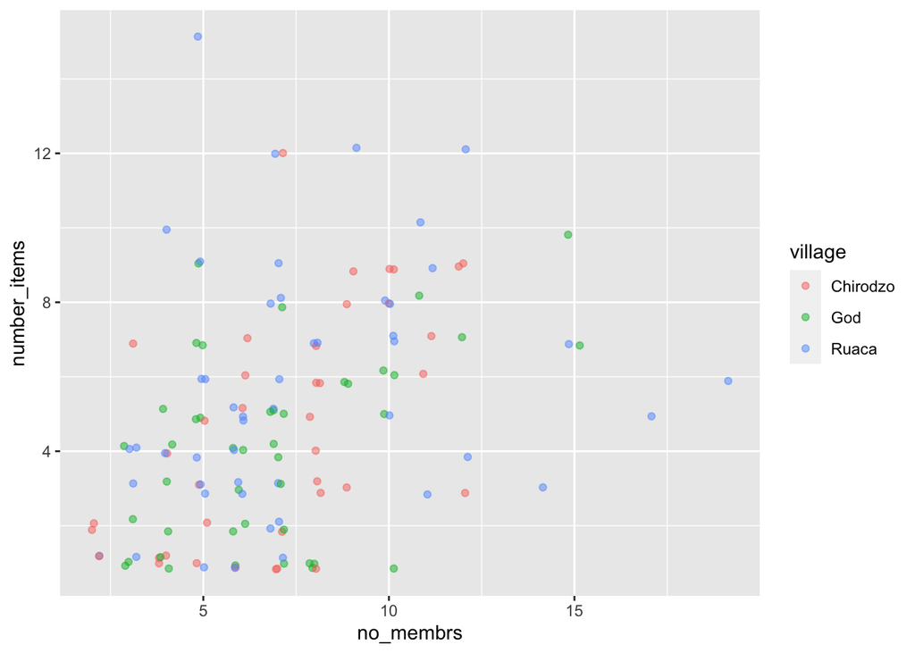

```r
interviews_plotting %>%
    ggplot(aes(x = no_membrs, y = number_items, color = village)) +
    geom_jitter(alpha = 0.5, width = 0.2, height = 0.2)
```